# GroupProject

```python
import pandas as pd
```

```python
file= '/Users/Dell/Documents/3mtt project/dataset/supermarket_sales - Sheet1.csv'
data= pd.read_csv(file)
```

```python
data.head()
```

|  | Invoice ID | Branch | City | Customer type | Gender | Product line | Unit price | Quantity | Tax 5% | Total | Date | Time | Payment | cogs | gross margin percentage | gross income | Rating |
| --- | --- | --- | --- | --- | --- | --- | --- | --- | --- | --- | --- | --- | --- | --- | --- | --- | --- |
| 0 | 750-67-8428 | A | Yangon | Member | Female | Health and beauty | 74.69 | 7 | 26.1415 | 548.9715 | 1/5/2019 | 13:08 | Ewallet | 522.83 | 4.761905 | 26.1415 | 9.1 |
| 1 | 226-31-3081 | C | Naypyitaw | Normal | Female | Electronic accessories | 15.28 | 5 | 3.8200 | 80.2200 | 3/8/2019 | 10:29 | Cash | 76.40 | 4.761905 | 3.8200 | 9.6 |
| 2 | 631-41-3108 | A | Yangon | Normal | Male | Home and lifestyle | 46.33 | 7 | 16.2155 | 340.5255 | 3/3/2019 | 13:23 | Credit card | 324.31 | 4.761905 | 16.2155 | 7.4 |
| 3 | 123-19-1176 | A | Yangon | Member | Male | Health and beauty | 58.22 | 8 | 23.2880 | 489.0480 | 1/27/2019 | 20:33 | Ewallet | 465.76 | 4.761905 | 23.2880 | 8.4 |
| 4 | 373-73-7910 | A | Yangon | Normal | Male | Sports and travel | 86.31 | 7 | 30.2085 | 634.3785 | 2/8/2019 | 10:37 | Ewallet | 604.17 | 4.761905 | 30.2085 | 5.3 |

```python
data.tail()
```

|  | Invoice ID | Branch | City | Customer type | Gender | Product line | Unit price | Quantity | Tax 5% | Total | Date | Time | Payment | cogs | gross margin percentage | gross income | Rating |
| --- | --- | --- | --- | --- | --- | --- | --- | --- | --- | --- | --- | --- | --- | --- | --- | --- | --- |
| 995 | 233-67-5758 | C | Naypyitaw | Normal | Male | Health and beauty | 40.35 | 1 | 2.0175 | 42.3675 | 1/29/2019 | 13:46 | Ewallet | 40.35 | 4.761905 | 2.0175 | 6.2 |
| 996 | 303-96-2227 | B | Mandalay | Normal | Female | Home and lifestyle | 97.38 | 10 | 48.6900 | 1022.4900 | 3/2/2019 | 17:16 | Ewallet | 973.80 | 4.761905 | 48.6900 | 4.4 |
| 997 | 727-02-1313 | A | Yangon | Member | Male | Food and beverages | 31.84 | 1 | 1.5920 | 33.4320 | 2/9/2019 | 13:22 | Cash | 31.84 | 4.761905 | 1.5920 | 7.7 |
| 998 | 347-56-2442 | A | Yangon | Normal | Male | Home and lifestyle | 65.82 | 1 | 3.2910 | 69.1110 | 2/22/2019 | 15:33 | Cash | 65.82 | 4.761905 | 3.2910 | 4.1 |
| 999 | 849-09-3807 | A | Yangon | Member | Female | Fashion accessories | 88.34 | 7 | 30.9190 | 649.2990 | 2/18/2019 | 13:28 | Cash | 618.38 | 4.761905 | 30.9190 | 6.6 |

```python
data.info()
```

```
<class 'pandas.core.frame.DataFrame'>
RangeIndex: 1000 entries, 0 to 999
Data columns (total 17 columns):
 #   Column                   Non-Null Count  Dtype
---  ------                   --------------  -----
 0   Invoice ID               1000 non-null   object
 1   Branch                   1000 non-null   object
 2   City                     1000 non-null   object
 3   Customer type            1000 non-null   object
 4   Gender                   1000 non-null   object
 5   Product line             1000 non-null   object
 6   Unit price               1000 non-null   float64
 7   Quantity                 1000 non-null   int64
 8   Tax 5%                   1000 non-null   float64
 9   Total                    1000 non-null   float64
 10  Date                     1000 non-null   object
 11  Time                     1000 non-null   object
 12  Payment                  1000 non-null   object
 13  cogs                     1000 non-null   float64
 14  gross margin percentage  1000 non-null   float64
 15  gross income             1000 non-null   float64
 16  Rating                   1000 non-null   float64
dtypes: float64(7), int64(1), object(9)
memory usage: 132.9+ KB
```

```python
data.duplicated().sum()
```

```
0
```

```python
data.columns
```

```
Index(['Invoice ID', 'Branch', 'City', 'Customer type', 'Gender',
       'Product line', 'Unit price', 'Quantity', 'Tax 5%', 'Total', 'Date',
       'Time', 'Payment', 'cogs', 'gross margin percentage', 'gross income',
       'Rating'],
      dtype='object')
```

```python
data.shape
```

```
(1000, 17)
```

```python
data.size
```

```
17000
```

```python
data.isnull().sum()
```

```
Invoice ID                 0
Branch                     0
City                       0
Customer type              0
Gender                     0
Product line               0
Unit price                 0
Quantity                   0
Tax 5%                     0
Total                      0
Date                       0
Time                       0
Payment                    0
cogs                       0
gross margin percentage    0
gross income               0
Rating                     0
dtype: int64
```

**EDA; univariate analyis**

```python
data['Product line'].mode()
```

```
0    Fashion accessories
Name: Product line, dtype: object
```

```python
data['Product line'].value_counts()
```

```
Product line
Fashion accessories       178
Food and beverages        174
Electronic accessories    170
Sports and travel         166
Home and lifestyle        160
Health and beauty         152
Name: count, dtype: int64
```

```python
data['Quantity'].value_counts()
```

```
Quantity
10    119
1     112
4     109
7     102
5     102
6      98
9      92
2      91
3      90
8      85
Name: count, dtype: int64
```

```python
import matplotlib.pyplot as plt
import seaborn as sns
```

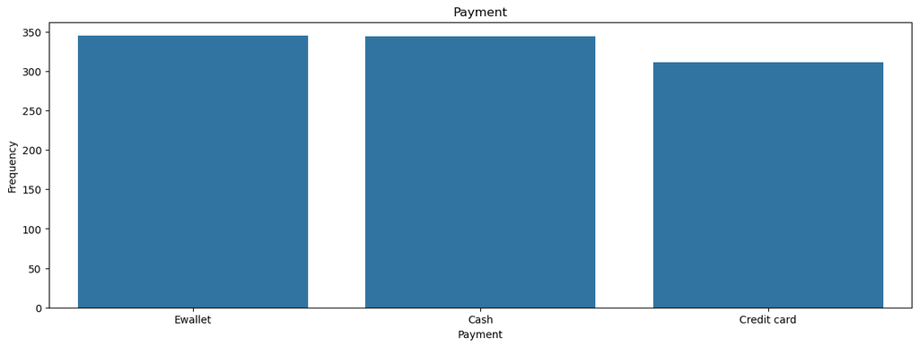

```python
# # plot of paymnet diatribution (countplot)
plt.figure(figsize=(15,5))
sns.countplot(x='Payment', data=data,)
plt.title('Payment')
plt.xlabel('Payment')
plt.ylabel('Frequency')
plt.show()
```

**INSIGHT**

- There was more customer willing to purchase the supermarket product with cash than those buying on credit

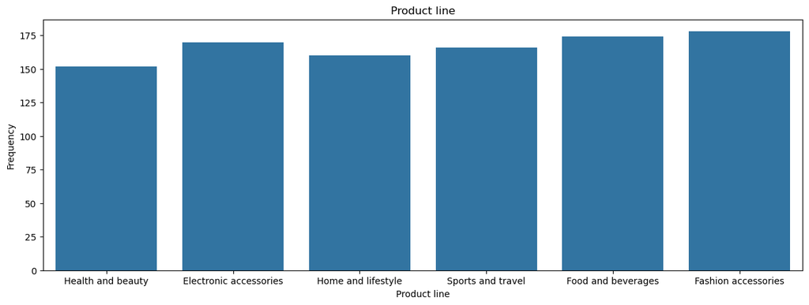

```python
# # plot of product line diatribution (countplot)
plt.figure(figsize=(15,5))
sns.countplot(x='Product line', data=data,)
plt.title('Product line')
plt.xlabel('Product line')
plt.ylabel('Frequency')
plt.show()
```

**INSHIGHT**

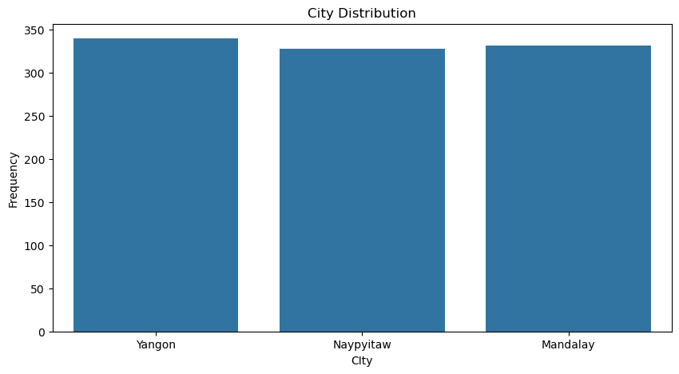

```python
# plot of city diatribution (countplot)
plt.figure(figsize=(10,5))
sns.countplot(x='City', data=data,)
plt.title('City Distribution')
plt.xlabel('CIty')
plt.ylabel('Frequency')
plt.show()
```

**INSIGHT**

**EDA; Bivariate Analysis**

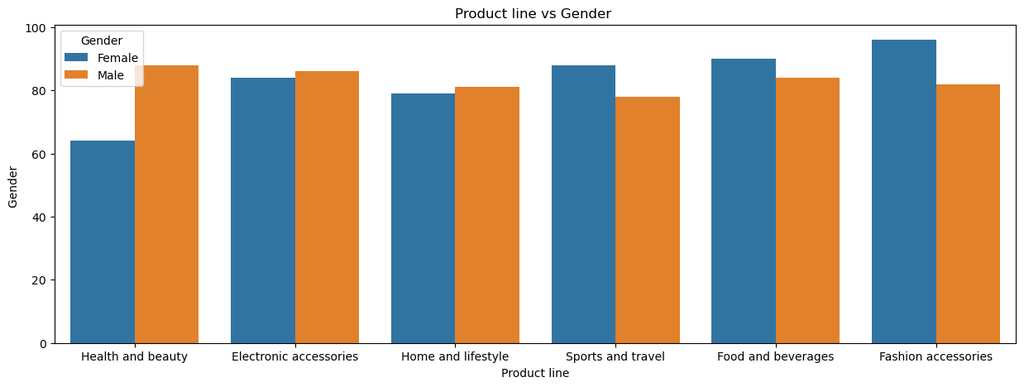

```python
# get relationship btw Product line and Gender
plt.figure(figsize=(15,5))
sns.countplot(x='Product line', data=data, hue='Gender')
plt.title('Product line vs Gender ')
plt.xlabel('Product line')
plt.ylabel('Gender ')
plt.show()
```

**INSIGHT**

- female bought more of fashion accessories than man
- The male gender bought more of the supermarket health product

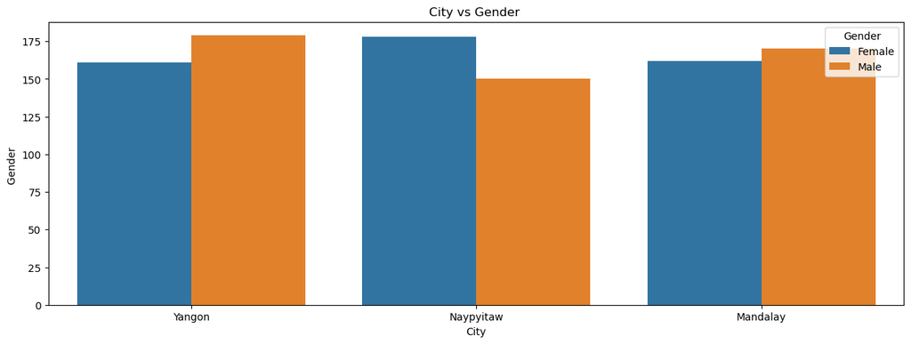

```python
# plot relationship btw City and Gender
plt.figure(figsize=(15,5))
sns.countplot(x='City', data=data, hue='Gender')
plt.title('City vs Gender ')
plt.xlabel('City')
plt.ylabel('Gender ')
plt.show()
```

**INSIGHT**

- In the city of Naypyitaw woman are willing to buy their product than the female counterpant

```python
data.info()
```

```
<class 'pandas.core.frame.DataFrame'>
RangeIndex: 1000 entries, 0 to 999
Data columns (total 17 columns):
 #   Column                   Non-Null Count  Dtype
---  ------                   --------------  -----
 0   Invoice ID               1000 non-null   object
 1   Branch                   1000 non-null   object
 2   City                     1000 non-null   object
 3   Customer type            1000 non-null   object
 4   Gender                   1000 non-null   object
 5   Product line             1000 non-null   object
 6   Unit price               1000 non-null   float64
 7   Quantity                 1000 non-null   int64
 8   Tax 5%                   1000 non-null   float64
 9   Total                    1000 non-null   float64
 10  Date                     1000 non-null   object
 11  Time                     1000 non-null   object
 12  Payment                  1000 non-null   object
 13  cogs                     1000 non-null   float64
 14  gross margin percentage  1000 non-null   float64
 15  gross income             1000 non-null   float64
 16  Rating                   1000 non-null   float64
dtypes: float64(7), int64(1), object(9)
memory usage: 132.9+ KB
```

**HYPOTHESIS**

- **ALTERNATIVE HYPOTHESIS:** There is significant relationship between Unit Price and Quatity
- **NULL HYPOTESIS:** There is no significant relationship between Gross Income and Unit Price

```python
# using pearson correlation technique
import scipy.stats as stats
```

```python
selected_data = data[['gross income', 'Unit price']]
selected_data.isna().sum()
```

```
gross income    0
Unit price      0
dtype: int64
```

```python
# get pearson correlation between the two variables
pearson_value, p_value = stats.pearsonr(selected_data['gross income'],selected_data['Unit price'])
```

```python
data.info()
```

```
<class 'pandas.core.frame.DataFrame'>
RangeIndex: 1000 entries, 0 to 999
Data columns (total 17 columns):
 #   Column                   Non-Null Count  Dtype
---  ------                   --------------  -----
 0   Invoice ID               1000 non-null   object
 1   Branch                   1000 non-null   object
 2   City                     1000 non-null   object
 3   Customer type            1000 non-null   object
 4   Gender                   1000 non-null   object
 5   Product line             1000 non-null   object
 6   Unit price               1000 non-null   float64
 7   Quantity                 1000 non-null   int64
 8   Tax 5%                   1000 non-null   float64
 9   Total                    1000 non-null   float64
 10  Date                     1000 non-null   object
 11  Time                     1000 non-null   object
 12  Payment                  1000 non-null   object
 13  cogs                     1000 non-null   float64
 14  gross margin percentage  1000 non-null   float64
 15  gross income             1000 non-null   float64
 16  Rating                   1000 non-null   float64
dtypes: float64(7), int64(1), object(9)
memory usage: 132.9+ KB
```

```python
x = round(pearson_value,4)
y = p_value
print(f'pearson correlation value of selected_data is {x} and p_value is {y}')
```

```
pearson correlation value of selected_data is 0.634 and p_value is 1.6099520923653275e-113
```

**INSIGHT**

- The correlation coefficient (r = 0.634) indicates a moderate to strong positive linear relationship between gross income and unit price.
- The p-value (1.6099520923653275e-113) confirms that the observed correlation is statistically significant,
- The null hypothesis of no correlation is rejected.
- As gross income increases, unit price tends to increase
- The correlation may indicate that products or services with higher unit prices are more affordable for individuals with higher gross incomes.

```python
selected_data = data[['Unit price', 'Quantity']]
selected_data.isna().sum()
```

```
Unit price    0
Quantity      0
dtype: int64
```

```python
# get pearson correlation between the two variables
pearson_value, p_value = stats.pearsonr(selected_data['Unit price'],selected_data['Quantity'])
```

```python
data.info()
```

```
<class 'pandas.core.frame.DataFrame'>
RangeIndex: 1000 entries, 0 to 999
Data columns (total 17 columns):
 #   Column                   Non-Null Count  Dtype
---  ------                   --------------  -----
 0   Invoice ID               1000 non-null   object
 1   Branch                   1000 non-null   object
 2   City                     1000 non-null   object
 3   Customer type            1000 non-null   object
 4   Gender                   1000 non-null   object
 5   Product line             1000 non-null   object
 6   Unit price               1000 non-null   float64
 7   Quantity                 1000 non-null   int64
 8   Tax 5%                   1000 non-null   float64
 9   Total                    1000 non-null   float64
 10  Date                     1000 non-null   object
 11  Time                     1000 non-null   object
 12  Payment                  1000 non-null   object
 13  cogs                     1000 non-null   float64
 14  gross margin percentage  1000 non-null   float64
 15  gross income             1000 non-null   float64
 16  Rating                   1000 non-null   float64
dtypes: float64(7), int64(1), object(9)
memory usage: 132.9+ KB
```

```python
x = round(pearson_value,4)
y = p_value
print(f'pearson correlation value of selected_data is {x} and p_value is {y}')
```

```
pearson correlation value of selected_data is 0.0108 and p_value is 0.7335552210347178
```

**INSIGHT**

- The correlation coefficient r = 0.0108 indicates a very weak linear relationship between quantity and unit price.
- The p-value (0.7336) is greater than the typical significance level (α = 0.05)
- The very weak correlation suggests that changes in quantity do not have a significant impact on unit price.
- Unit price may not be sensitive to changes in quantity, allowing for more flexibility in pricing decisions.
- We reject the alternative hypothesis because there is no significant linear relationship between quantity and price.